# SU_25_River_Rockfish_Proj_Fecundity_V0.2

River Mckegney

2025-07-28

## Setup, and Packages

Code Packages:

```r
# Load packages
library(gridExtra) # For using grid.table to save tables as images
library(flextable) # Alternative method to save df as image
library(tidyverse)
library(zoo)
library(lme4)
library(lmerTest)
library(rlang)
library(nortest) # For ad.test
library(car) # For homogeneity of variance with leveneTest
library(rcompanion) # For scheirerRayHare test
library(pastecs) # For stat.desc
library(ggpubr) # For assumption plots
library(conover.test) # For the conover.Iman() test function
library(DescTools) # Contain alternative ConoverTest function
library(rstatix) # tidyverse adapted stat tests and mshapiro_test() functions
library(DHARMa) # For multi-level lm models and shapiro test
library(patchwork) # For combining ggplots
```

## Data Entry: Read-in data

```r
# Read and call data into df

# Primary samples df
ABL90 <- read.csv("Raw_Data/ABL90_Raw.csv")

# River's Parturition metadata
partuition_subcat <- read.csv("Raw_Data/River's_Rockfish_Metadata_Parturition_V7.csv")
```

## Data Filtering

```r
# Data sifting: ABL90 dataset

# Step 1: Remove missing info
ABL_set1 <- ABL90 %>%
  filter(Patient.ID_edited != "")


# Step 2: Separate Patient.ID into columns of sample types: blood plasma and instant freeze plasma
ABL_set2 <- separate(ABL_set1, 'Patient.ID_edited', into = c("Patient.ID_edited", "Sample_Type"), sep = ",")
# Step 3:
# Convert Patient.ID_edited column data to character type
ABL_set2$Patient.ID_edited <- as.character(ABL_set2$Patient.ID_edited)
```

```r
# Step 4 & 5: Sussing out specific sample errors

# Remove insufficient samples
ABL_set3 <- ABL_set2 %>%
  filter(!is.na("Type")) %>%
  filter(!str_detect(Errors.detected.during.measurement, "Insufficient sample"))

# Remove inhomogeneous samples
ABL_set3 <- ABL_set3 %>%
  filter(!is.na("Type")) %>%
  filter(!str_detect(Errors.detected.during.measurement, "Inhomogeneous sample"))

# Step 6: Filter for only blood samples
ABL_b_samp <- ABL_set3 %>%
  filter(Sample_Type == "b")
```

## Merge Datasets:

Join ABL90 df with parturition_subcat df: Making ABL_merged

```r
# Rename columns to match: Change 'ID' in parturition_subcat to 'Patient.ID_edited' so it is ready to join with ABL90 df

# Please note the 'Treatment' col in parturition_subcat does not match with the finalized 'Ambient.Or.OAH' col in metadata_atresia_guide or ABL90_merged df

# Rename 'ID' col to 'patient.ID_edited'
partuition_subcat <- partuition_subcat %>%
  rename(Patient.ID_edited = ID)
```

```r
# Connect main ABL90 dataset with my (River's) sub categorized parturition metadata
# ABL_merged <- partuition_subcat %>%
# left_join(ABL_b_samp, by = "Patient.ID_edited")

ABL_merged <- ABL_b_samp %>%
inner_join(partuition_subcat, by = "Patient.ID_edited")
```

Rename Columns Neatly:

```r
# Rename Treatment & Parturition Outcome
ABL_merged <- ABL_merged %>%
  rename(Ambient.Or.OAH = Consensus_General_Treatment,
         Pregnant.Or.Atresia = Consensus_Atresia_Or_Pregnant)
```

## Remove Samples: Mortalities, NA’s, or Missing Info, and Replicates

Remove Replicate ID’s

```r
# Cross Check all Columns: Cross validation to suss correct replicate row
check_params <- ABL_merged %>%
  select(Patient.ID_edited, Time, Sample.., Measuring.Mode, Ambient.Or.OAH, Pregnant.Or.Atresia, pH, Glu..mmol.L., Hct...., Na...mmol.L., Cl...mmol.L., K...mmol.L., Ca....mmol.L., pCO2..mmHg.) %>%
  filter(Patient.ID_edited == "9782D")
print(check_params)
```

```
##   Patient.ID_edited             Time Sample.. Measuring.Mode Ambient.Or.OAH
## 1             9782D 12/28/2023 10:04     1016         C 65uL        Ambient
## 2             9782D   1/9/2024 17:21      863         S 65uL        Ambient
##   Pregnant.Or.Atresia    pH Glu..mmol.L. Hct.... Na...mmol.L. Cl...mmol.L.
## 1    Post Parturition 7.348          0.5     9.8          184          149
## 2    Post Parturition 7.446          0.7    13.3          181          161
##   K...mmol.L. Ca....mmol.L. pCO2..mmHg.
## 1         2.8          1.32         4.2
## 2         2.9          1.31         6.8
```

```r
check_params <- ABL_merged %>%
  select(Patient.ID_edited, Time, Sample.., Measuring.Mode, Ambient.Or.OAH, Pregnant.Or.Atresia, pH, Glu..mmol.L., Hct...., Na...mmol.L., Cl...mmol.L., K...mmol.L., Ca....mmol.L., pCO2..mmHg.) %>%
  filter(Patient.ID_edited == "9783D")
print(check_params)
```

```
##   Patient.ID_edited            Time Sample.. Measuring.Mode Ambient.Or.OAH
## 1             9783D 1/19/2024 10:37      934         S 65uL        Ambient
## 2             9783D  1/7/2024 12:32      860         S 65uL        Ambient
##   Pregnant.Or.Atresia    pH Glu..mmol.L. Hct.... Na...mmol.L. Cl...mmol.L.
## 1    Post Parturition 7.484          1.7     0.2          175          193
## 2    Post Parturition 7.450          1.3    14.7          179          164
##   K...mmol.L. Ca....mmol.L. pCO2..mmHg.
## 1        34.5          1.29         8.5
## 2         2.5          1.30         5.3
```

```r
# Removed replicates: 9782D (2x) and 9783D (2x)
ABL_merged <- ABL_merged %>%
  filter(Sample.. != "863",
         Sample.. != "934")
```

Review Replicates:

| Row | ID | Time | Sample.. | Measuring.Mode | pH | Glu.mmol.L. | Hct…. | Na…mmol.L. | Cl…mmol.L. | K…mmol.L. | Ca.mmol.L. |
| --- | --- | --- | --- | --- | --- | --- | --- | --- | --- | --- | --- |
| 32 | 9782D | 12/28/2023 10:04 | 1016 | C 65uL | 7.348 | 0.5 | 9.8 | 184 | 149 | 2.8 | 1.32 |
| 39 | 9782D | 1/9/2024 17:21 | 863 | S 65uL | 7.446 | 0.7 | 13.3 | 181 | 161 | 2.9 | 1.31 |
| 36 | 9783D | 1/19/2024 10:37 | 934 | S 65uL | 7.484 | 1.7 | **0.2** | 175 | 193 | **34.5** | 1.29 |
| 41 | 9783D | 1/7/2024 12:32 | 860 | S 65uL | 7.450 | 1.3 | **14.7** | 179 | 164 | **2.5** | 1.30 |

Methods for replicate sample removal: Check processing date of IDs, and remove samples that do not match that date.

Case ID_9782D:

- Origianl ABL90 set contains:
- 9782D,b (Sample.. 1016, Time = 12/28/2023 10:04:00 AM)
- 9782D,p (Sample.. 1020, Time = 12/28/2023 10:25:00 AM)
- 9782D,p (Sample.. 865, Time = 1/9/2024 5:29:00 PM)
- 9782D,b (Sample.. 863, Time = 1/9/2024 5:21:00 PM)
- 2024_Fish_Metadata.csv says ID_9782D was processed 3/29/2024
- Note Processing date in metadata will not match time date stamp in ABL90 data due to the machine being reset, and innacurrate dates being automatically recorded.

Deciding info: - For ID-9782D, refer to metadata sheet and look for other samples with that same processing date, then view thoes samples ABL90 ‘Time’. Try to find a matching ‘Time’ with other IDs and 9782D that were processed together during the same time recorded by the machine.

Case ID_9783D

- Original ABL90 dataset contains:
- 9783D,b (Sample.. 934, Time = 1/19/2024 10:37:00 AM)
- 9783D,c (Sample.. 861, Time = 1/7/2024 12:38:00 PM)
- 9783D,b (Sample.. 860, Time = 1/7/2024 12:32:00 PM)
- 2024_Fish_Metadata.csv says ID_9783D was processed 3/20/2024
- Informed that ID_9783D: Sample.. 934 is a plasma sample (on account of its low hct value), remove this and **keep Sample.. 860 (parameter values appear correct)**.

# Samples: Data subsets

Remove Motalities and No info IDs and assign analysis ready data-frames:

```r
# New df with Moralities removed: Note none of these samples made it into ABL90 df anyway, so looks like they are already filtered out.
 Live_Samples <- ABL_merged %>%
  filter(Patient.ID_edited != "9780C", # Mortality
         Patient.ID_edited != "777AE", # Mortality
         Patient.ID_edited != "777CA") # Mortality after parturition


# New df with mortality and 'No info' Id's removed
 Primary_Samples <- Live_Samples %>%
   filter(Patient.ID_edited != "777A0", # No info
           Patient.ID_edited != "9782F", # No info
           Patient.ID_edited != "777B3", # No info
           Patient.ID_edited != "777AA", # No info
           Patient.ID_edited != "777DE", # No info
           Patient.ID_edited != "777CE", # No info
           Patient.ID_edited != "777A6") # No info


# New df of Only Ambient Treatment: For testing parturition success
 Ambient_Samples <- Primary_Samples %>%
   filter(Ambient.Or.OAH == "Ambient")

# New df of Fecundity Samples:
 Fecundity_Samples <- Primary_Samples %>%
   filter(Fecundity_Or_Brood_Count != "NA",
     Fecundity_Class != "NA") # removes 97706

# Fecundity samples without atresia Ids
 Fecundity_No_Atresia_Samples <- Primary_Samples %>%
   filter(Fecundity_Class != "NA",
          Fecundity_Class != "Atresia",
          All_Fecundity != "Na",
          All_Fecundity != 0)  # removes atresia IDs

# Fecundity Ambient Samples
 Amb_Fec_Samples <- Primary_Samples %>%
   filter(Ambient.Or.OAH == "Ambient",
          All_Fecundity != "NA") # removes OAH treatment samples and ID 97706

# Fecundity Ambient Samples without atresia Ids
 Amb_Fec_No_Atresia_Samples <- Primary_Samples %>%
   filter(Ambient.Or.OAH == "Ambient", # removes OAH treatment
          All_Fecundity != "NA", # removes all missing info IDs
          All_Fecundity != 0) # removes atresia IDs
```

Change Data Types:

```r
# Change Continuous Data to type to numeric, double, or factor

# Change data type of ions to factor or numeric
#glimpse(General_Samples)
#glimpse(Ambient_Samples)

Primary_Samples <- Primary_Samples %>%
  mutate(across(c(All_Fecundity, pH, Hct...., Glu..mmol.L., Na...mmol.L., Cl...mmol.L., K...mmol.L., Ca....mmol.L.), as.numeric))

Ambient_Samples <- Ambient_Samples %>%
  mutate(across(c(All_Fecundity, pH, Hct...., Glu..mmol.L., Na...mmol.L., Cl...mmol.L., K...mmol.L., Ca....mmol.L.), as.numeric))

Fecundity_Samples <- Fecundity_Samples %>%
  mutate(across(c(All_Fecundity, pH, Hct...., Glu..mmol.L., Na...mmol.L., Cl...mmol.L., K...mmol.L., Ca....mmol.L.), as.numeric))

Fecundity_No_Atresia_Samples <- Fecundity_Samples %>%
  mutate(across(c(All_Fecundity, pH, Hct...., Glu..mmol.L., Na...mmol.L., Cl...mmol.L., K...mmol.L., Ca....mmol.L.), as.numeric))

Amb_Fec_Samples <- Amb_Fec_Samples %>%
  mutate(across(c(All_Fecundity, pH, Hct...., Glu..mmol.L., Na...mmol.L., Cl...mmol.L., K...mmol.L., Ca....mmol.L.), as.numeric))

Amb_Fec_No_Atresia_Samples <- Amb_Fec_No_Atresia_Samples %>%
  mutate(across(c(All_Fecundity, pH, Hct...., Glu..mmol.L., Na...mmol.L., Cl...mmol.L., K...mmol.L., Ca....mmol.L.), as.numeric))

# glimpse(Primary_Samples)
# glimpse(Ambient_Samples)
# glimpse(Fecundity_Samples)
# glimpse(Amb_Fec_Samples)
```

## Order Factor Levels

```r
# Fecundity data

#unique(Fecundity_Samples$Fecundity_Class)

# Arrange the order of parturition categories for visualizations & tests

# Primary Samples

# Arrange Treatment
Primary_Samples$Ambient.Or.OAH <- ordered(Primary_Samples$Ambient.Or.OAH, levels = c("Ambient", "OAH"))

# Arrange Parturition outcome
Primary_Samples$Pregnant.Or.Atresia <- ordered(Primary_Samples$Pregnant.Or.Atresia, levels = c("Post Parturition", "Atresia"))

# Arrange Brood Condition
Primary_Samples$Consensus_Brood_Condition <- ordered(Primary_Samples$Consensus_Brood_Condition, levels = c("Excellent", "Normal", "Low", "Very Low", "Atresia"))

# Arrange Fecundity Class
Primary_Samples$Fecundity_Class <- ordered(Primary_Samples$Fecundity_Class, levels = c("High (>50,000)", "Low (~1,000s)", "Atresia"))

# Remove NAs from ordered character factors
Primary_Samples <- Primary_Samples %>%
  filter(Fecundity_Class != is.na(Fecundity_Class)) %>%
  filter(Consensus_Brood_Condition != is.na(Consensus_Brood_Condition))


# Ambient data
Ambient_Samples$Ambient.Or.OAH <- ordered(Ambient_Samples$Ambient.Or.OAH, levels = c("Ambient", "OAH"))

Ambient_Samples$Pregnant.Or.Atresia <- ordered(Ambient_Samples$Pregnant.Or.Atresia, levels = c("Post Parturition", "Atresia"))

Ambient_Samples$Consensus_Brood_Condition <- ordered(Ambient_Samples$Consensus_Brood_Condition, levels = c("Excellent", "Normal", "Low", "Atresia"))

Ambient_Samples$Fecundity_Class <- ordered(Ambient_Samples$Fecundity_Class, levels = c("High (>50,000)", "Low (~1,000s)", "Atresia"))

# Remove NAs from ordered character factors
Ambient_Samples <- Ambient_Samples %>%
  filter(Fecundity_Class != is.na(Fecundity_Class)) %>%
  filter(Consensus_Brood_Condition != is.na(Consensus_Brood_Condition))

# Ambient Fecundity data
Amb_Fec_No_Atresia_Samples$Ambient.Or.OAH <- ordered(Amb_Fec_No_Atresia_Samples$Ambient.Or.OAH, levels = c("Ambient", "OAH"))

Amb_Fec_No_Atresia_Samples$Pregnant.Or.Atresia <- ordered(Amb_Fec_No_Atresia_Samples$Pregnant.Or.Atresia, levels = c("Post Parturition", "Atresia"))

Amb_Fec_No_Atresia_Samples$Consensus_Brood_Condition <- ordered(Amb_Fec_No_Atresia_Samples$Consensus_Brood_Condition, levels = c("Excellent", "Normal", "Low", "Atresia"))

Amb_Fec_No_Atresia_Samples$Fecundity_Class <- ordered(Amb_Fec_No_Atresia_Samples$Fecundity_Class, levels = c("High (>50,000)", "Low (~1,000s)", "Atresia"))

# Remove NAs from ordered character factors
Amb_Fec_No_Atresia_Samples <- Amb_Fec_No_Atresia_Samples %>%
  filter(Fecundity_Class != is.na(Fecundity_Class)) %>%
  filter(Consensus_Brood_Condition != is.na(Consensus_Brood_Condition))


# Fecundity No Atresia data

Fecundity_No_Atresia_Samples$Ambient.Or.OAH <- ordered(Fecundity_No_Atresia_Samples$Ambient.Or.OAH, levels = c("Ambient", "OAH"))

Fecundity_No_Atresia_Samples$Pregnant.Or.Atresia <- ordered(Fecundity_No_Atresia_Samples$Pregnant.Or.Atresia, levels = c("Post Parturition", "Atresia"))

Fecundity_No_Atresia_Samples$Fecundity_Class <- ordered(Fecundity_No_Atresia_Samples$Fecundity_Class, levels = c("High (>50,000)", "Low (~1,000s)"))

Fecundity_No_Atresia_Samples$Fecundity_Class <-
  ordered(Fecundity_No_Atresia_Samples$Fecundity_Class, levels = c("High (>50,000)", "Low (~1,000s)"))

Fecundity_No_Atresia_Samples <- Fecundity_No_Atresia_Samples %>%
  filter(Fecundity_Class != is.na(Fecundity_Class)) %>%
  filter(Consensus_Brood_Condition != is.na(Consensus_Brood_Condition))
```

# Save filtered dataset into data-worked folder

```r
# Save merged dataset in a worked folder

write.csv(x = Primary_Samples, file = "Worked-Data/Primary_Samples")

write.csv(x = Ambient_Samples, file = "Worked-Data/Ambient_Samples")

write.csv(x = Fecundity_Samples, file = "Worked-Data/Fecundity_Samples")

write.csv(x = Fecundity_No_Atresia_Samples, file = "Worked-Data/Fecundity_No_Atresia_Samples")

write.csv(x = Amb_Fec_Samples, file = "Worked-Data/Amb-Fec_Samples")

write.csv(x = Amb_Fec_No_Atresia_Samples, file = "Worked-Data/Amb_Fec_No_Atresia_Samples")
```

## Sample Size: n

```r
# Sample Size

Fec_NA_sample_size_table <- Fecundity_No_Atresia_Samples %>%
  group_by(Ambient.Or.OAH) %>%
  summarise(n_size = n_distinct(Patient.ID_edited), .groups = "drop")
print(Fec_NA_sample_size_table)
```

```
## # A tibble: 2 × 2
##   Ambient.Or.OAH n_size
##   <ord>           <int>
## 1 Ambient             8
## 2 OAH                 2
```

```r
 pdf("data-images/Fec_NA_sample_size_table.pdf")
 grid.table(Fec_NA_sample_size_table)
 dev.off()
```

```r
 png("data-images/Fec_NA_sample_size_table.png")
 grid.table(Fec_NA_sample_size_table)
 dev.off()
```

```r
Fecundity_No_Atresia_Samples %>%
  group_by(Ambient.Or.OAH, Fecundity_Class) %>%
  summarise(n_size = n_distinct(Patient.ID_edited), .groups = "drop")
```

```
## # A tibble: 3 × 3
##   Ambient.Or.OAH Fecundity_Class n_size
##   <ord>          <ord>            <int>
## 1 Ambient        High (>50,000)       4
## 2 Ambient        Low (~1,000s)        4
## 3 OAH            High (>50,000)       2
```

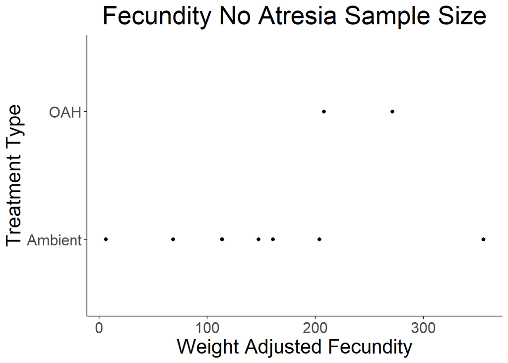

```r
# View Sample Distributions
# Sample Size barplot
# Fecundity Samples

# Fecundity No atresia sample size

# Fec_NA_barplot <- Fecundity_No_Atresia_Samples %>%
#   group_by(Fecundity_Class, Ambient.Or.OAH) %>%
#   summarise(n_size = n_distinct(Patient.ID_edited), .groups = "drop") %>%
#   ggplot(aes(x = Fecundity_Class, y = n_size)) +
#   geom_bar(stat = "identity") +
#   facet_grid(~ Ambient.Or.OAH) +
#   scale_y_continuous(expand = c(0, 0), limits = c(0, 15.5), breaks = c(4, 8, 12)) +
#   labs(title = "Fecundity No Atresia Sample Size",
#         x = "Parturition Outcome",
#         y = "Sample Size (n)") +
#   theme_classic() +
#   theme(panel.background = element_rect(fill = "white"),
#         plot.background = element_rect(fill = "white"),
#         legend.background = element_rect(fill = "white", color = "black"),
#         title = element_text(size = 12),
#         plot.title = element_text(size = 25, hjust = 0.5),
#         axis.text.x = element_text(size = 13),
#         axis.text.y = element_text(size = 20),
#         axis.title.x = element_text(size = 20),
#         axis.title.y = element_text(size = 20))
#
# print(Fec_NA_barplot)
#
# ggsave(filename = "data-images/.png", plot = Fec_NA_barplot, device = "png")
# ggsave(filename = "data-images/Fec_NA_barplot.pdf", plot = Fec_NA_barplot, device = "pdf")


Fec_NA_Scatterplot_Samples <- Fecundity_No_Atresia_Samples %>%
  ggplot(aes(x = Weight_Adjusted_Fecundity_Fecundity.Mean_Weight, y = Ambient.Or.OAH)) +
  geom_point() +
  labs(title = "Fecundity No Atresia Sample Size",
        x = "Weight Adjusted Fecundity",
        y = "Treatment Type") +
  theme_classic() +
  theme(panel.background = element_rect(fill = "white"),
        plot.background = element_rect(fill = "white"),
        legend.background = element_rect(fill = "white", color = "black"),
        title = element_text(size = 12),
        plot.title = element_text(size = 25, hjust = 0.5),
        axis.text.x = element_text(size = 15),
        axis.text.y = element_text(size = 15),
        axis.title.x = element_text(size = 20),
        axis.title.y = element_text(size = 20))
print(Fec_NA_Scatterplot_Samples)
```

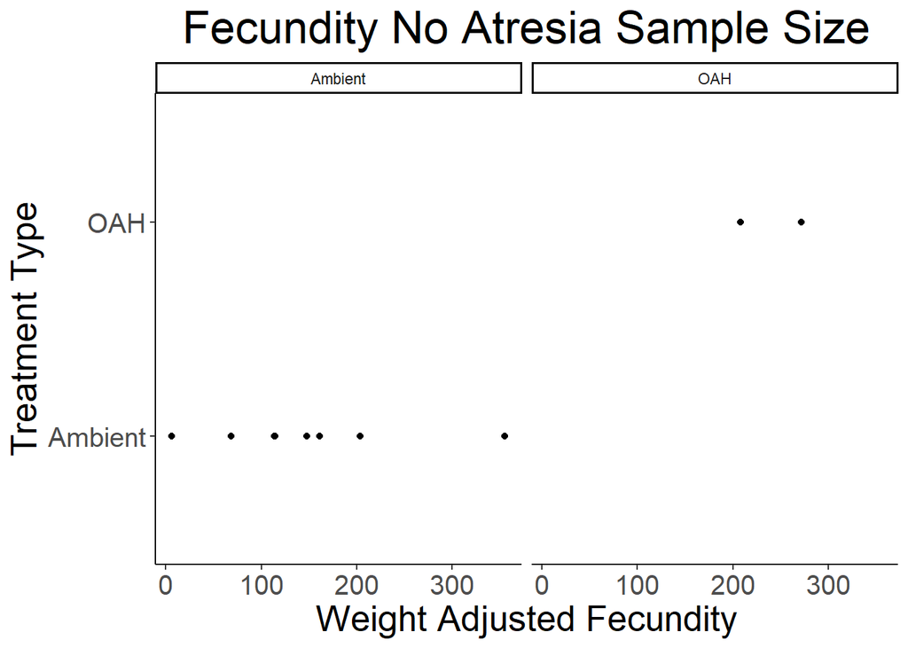

```r
ggsave(filename = "data-images/.png", plot = Fec_NA_Scatterplot_Samples, device = "png")
ggsave(filename = "data-images/Fec_NA_Scatterplot_Samples.pdf", plot = Fec_NA_Scatterplot_Samples, device = "pdf")
Fec_NA_Scatterplot_Samples2 <- Fecundity_No_Atresia_Samples %>%
  ggplot(aes(x = Weight_Adjusted_Fecundity_Fecundity.Mean_Weight, y = Ambient.Or.OAH)) +
  geom_point() +
  facet_wrap(~Ambient.Or.OAH) +
  labs(title = "Fecundity No Atresia Sample Size",
        x = "Weight Adjusted Fecundity",
        y = "Treatment Type") +
  theme_classic() +
  theme(panel.background = element_rect(fill = "white"),
        plot.background = element_rect(fill = "white"),
        legend.background = element_rect(fill = "white", color = "black"),
        title = element_text(size = 12),
        plot.title = element_text(size = 25, hjust = 0.5),
        axis.text.x = element_text(size = 15),
        axis.text.y = element_text(size = 15),
        axis.title.x = element_text(size = 20),
        axis.title.y = element_text(size = 20))
print(Fec_NA_Scatterplot_Samples2)
```

# pH

pH Summary Stats

```r
# pH
# Summary stats

# Ambient data
Fecundity_No_Atresia_Samples %>%
  group_by(Ambient.Or.OAH, Weight_Adjusted_Fecundity_Fecundity.Mean_Weight) %>%
  summarize(count = n(),
            median = round(median(pH), 3),
            mean = round(mean(pH), 3),
            sd = round(sd(pH), 3),
            cv = round(sd(pH)/mean(pH), 3)) %>%
  ungroup()
```

```
## # A tibble: 10 × 7
##    Ambient.Or.OAH Weight_Adjusted_Fecundity_Fec…¹ count median  mean    sd    cv
##    <ord>                                    <dbl> <int>  <dbl> <dbl> <dbl> <dbl>
##  1 Ambient                                   6.22     1   7.48  7.48    NA    NA
##  2 Ambient                                  68.8      1   7.51  7.51    NA    NA
##  3 Ambient                                 114.       1   7.51  7.51    NA    NA
##  4 Ambient                                 114.       1   7.43  7.43    NA    NA
##  5 Ambient                                 148.       1   7.39  7.39    NA    NA
##  6 Ambient                                 161.       1   7.32  7.32    NA    NA
##  7 Ambient                                 204.       1   7.45  7.45    NA    NA
##  8 Ambient                                 356.       1   7.43  7.43    NA    NA
##  9 OAH                                     208.       1   7.49  7.49    NA    NA
## 10 OAH                                     272.       1   7.41  7.41    NA    NA
## # ℹ abbreviated name: ¹Weight_Adjusted_Fecundity_Fecundity.Mean_Weight
```

pH scattterplot

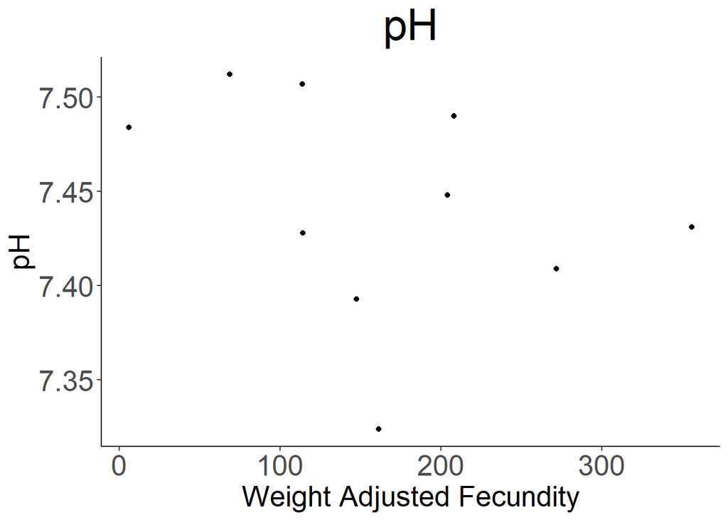

```r
# pH
# Fecundity No Atresia Samples

# Scatterplot
pH_fec_na_scatterplot <- Fecundity_No_Atresia_Samples %>%
  ggplot() +
  geom_point(aes(x = Weight_Adjusted_Fecundity_Fecundity.Mean_Weight, y = pH), colour = "black") +
  labs(title = "pH", x = "Weight Adjusted Fecundity", y = "pH") +
  theme_classic() +
  theme(panel.background = element_rect(fill = "white"),
        plot.background = element_rect(fill = "white"),
        legend.background = element_rect(fill = "white", color = "black"),
        title = element_text(size = 12),
        plot.title = element_text(size = 30, hjust = 0.5),
        axis.text.x = element_text(size = 20),
        axis.text.y = element_text(size = 20),
        axis.title.x = element_text(size = 20),
        axis.title.y = element_text(size = 20))

print(pH_fec_na_scatterplot)
```

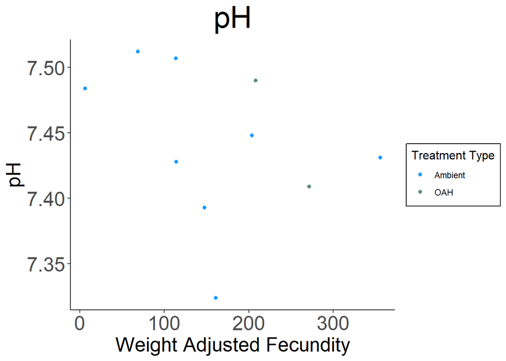

```r
ggsave(filename = "data-images/pH_fec_na_scatterplot.pdf", plot = pH_fec_na_scatterplot, device = "pdf")
ggsave(filename = "data-images/pH_fec_na_scatterplot.png", plot = pH_fec_na_scatterplot, device = "png")
# Color by treatment
pH_fec_na_scatterplot2 <- Fecundity_No_Atresia_Samples %>%
  ggplot() +
  geom_point(aes(x = Weight_Adjusted_Fecundity_Fecundity.Mean_Weight, y = pH, col = Ambient.Or.OAH)) +
  labs(title = "pH", x = "Weight Adjusted Fecundity", y = "pH") +
  theme_classic() +
  guides(color = guide_legend((title = "Treatment Type"))) +
  scale_color_manual(values = c("Ambient" = "#189bff", "OAH" = "#598c78")) +
  theme(panel.background = element_rect(fill = "white"),
        plot.background = element_rect(fill = "white"),
        legend.background = element_rect(fill = "white", color = "black"),
        title = element_text(size = 12),
        plot.title = element_text(size = 30, hjust = 0.5),
        axis.text.x = element_text(size = 20),
        axis.text.y = element_text(size = 20),
        axis.title.x = element_text(size = 20),
        axis.title.y = element_text(size = 20))

print(pH_fec_na_scatterplot2)
```

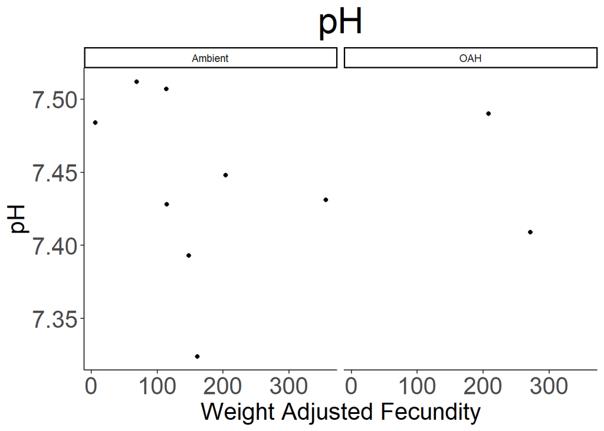

```r
# Facet by treatment
pH_fec_na_scatterplot3 <- Fecundity_No_Atresia_Samples %>%
  ggplot() +
  geom_point(aes(x = Weight_Adjusted_Fecundity_Fecundity.Mean_Weight, y = pH), colour = "black") +
  labs(title = "pH", x = "Weight Adjusted Fecundity", y = "pH") +
  facet_wrap(~ Ambient.Or.OAH) +
  theme_classic() +
  theme(panel.background = element_rect(fill = "white"),
        plot.background = element_rect(fill = "white"),
        legend.background = element_rect(fill = "white", color = "black"),
        title = element_text(size = 12),
        plot.title = element_text(size = 30, hjust = 0.5),
        axis.text.x = element_text(size = 20),
        axis.text.y = element_text(size = 20),
        axis.title.x = element_text(size = 20),
        axis.title.y = element_text(size = 20))

print(pH_fec_na_scatterplot3)
```

# pH Stat Tests

Weight Adjusted Fecundity, No Atresia

```r
# pH
# Weight Adjusted Fecundity, No Atresia

# Install flexplot
# devtools::install_github("dustinfife/flexplot", ref="development")
require(flexplot)
# Fancy lm model

# Interactive
pH_fec_na_lm <- lm(pH ~ Ambient.Or.OAH * Weight_Adjusted_Fecundity_Fecundity.Mean_Weight, data = Fecundity_No_Atresia_Samples)
summary(pH_fec_na_lm)
```

```
##
## Call:
## lm(formula = pH ~ Ambient.Or.OAH * Weight_Adjusted_Fecundity_Fecundity.Mean_Weight,
##     data = Fecundity_No_Atresia_Samples)
##
## Residuals:
##       Min        1Q    Median        3Q       Max
## -0.113613 -0.015036  0.005949  0.032543  0.058871
##
## Coefficients:
##                                                                    Estimate
## (Intercept)                                                       7.6146882
## Ambient.Or.OAH.L                                                  0.1996881
## Weight_Adjusted_Fecundity_Fecundity.Mean_Weight                  -0.0007501
## Ambient.Or.OAH.L:Weight_Adjusted_Fecundity_Fecundity.Mean_Weight -0.0007458
##                                                                  Std. Error
## (Intercept)                                                       0.1712237
## Ambient.Or.OAH.L                                                  0.2421469
## Weight_Adjusted_Fecundity_Fecundity.Mean_Weight                   0.0007121
## Ambient.Or.OAH.L:Weight_Adjusted_Fecundity_Fecundity.Mean_Weight  0.0010071
##                                                                  t value
## (Intercept)                                                       44.472
## Ambient.Or.OAH.L                                                   0.825
## Weight_Adjusted_Fecundity_Fecundity.Mean_Weight                   -1.053
## Ambient.Or.OAH.L:Weight_Adjusted_Fecundity_Fecundity.Mean_Weight  -0.740
##                                                                  Pr(>|t|)
## (Intercept)                                                      8.66e-09 ***
## Ambient.Or.OAH.L                                                    0.441
## Weight_Adjusted_Fecundity_Fecundity.Mean_Weight                     0.333
## Ambient.Or.OAH.L:Weight_Adjusted_Fecundity_Fecundity.Mean_Weight    0.487
## ---
## Signif. codes:  0 '***' 0.001 '**' 0.01 '*' 0.05 '.' 0.1 ' ' 1
##
## Residual standard error: 0.06302 on 6 degrees of freedom
## Multiple R-squared:  0.2302, Adjusted R-squared:  -0.1547
## F-statistic: 0.5981 on 3 and 6 DF,  p-value: 0.6393
```

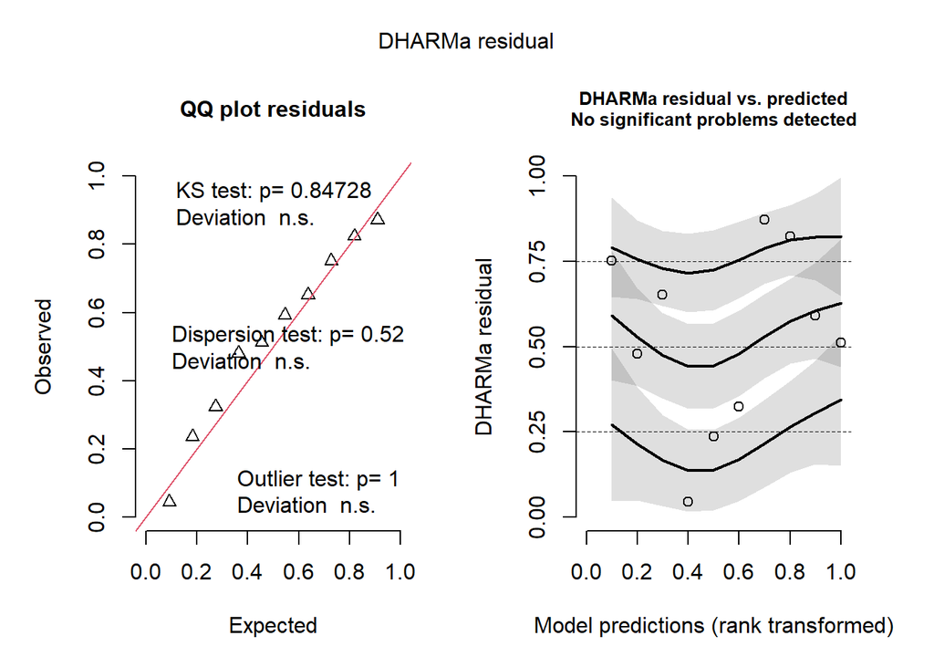

```r
pH_fec_na_lm_sim_res_plot <- simulateResiduals(fittedModel = pH_fec_na_lm)
plot(pH_fec_na_lm_sim_res_plot)
```

```
## qu = 0.25, log(sigma) = -3.378817 : outer Newton did not converge fully.
```

```
## qu = 0.5, log(sigma) = -3.478818 : outer Newton did not converge fully.
```

```
## qu = 0.5, log(sigma) = -3.526565 : outer Newton did not converge fully.
```

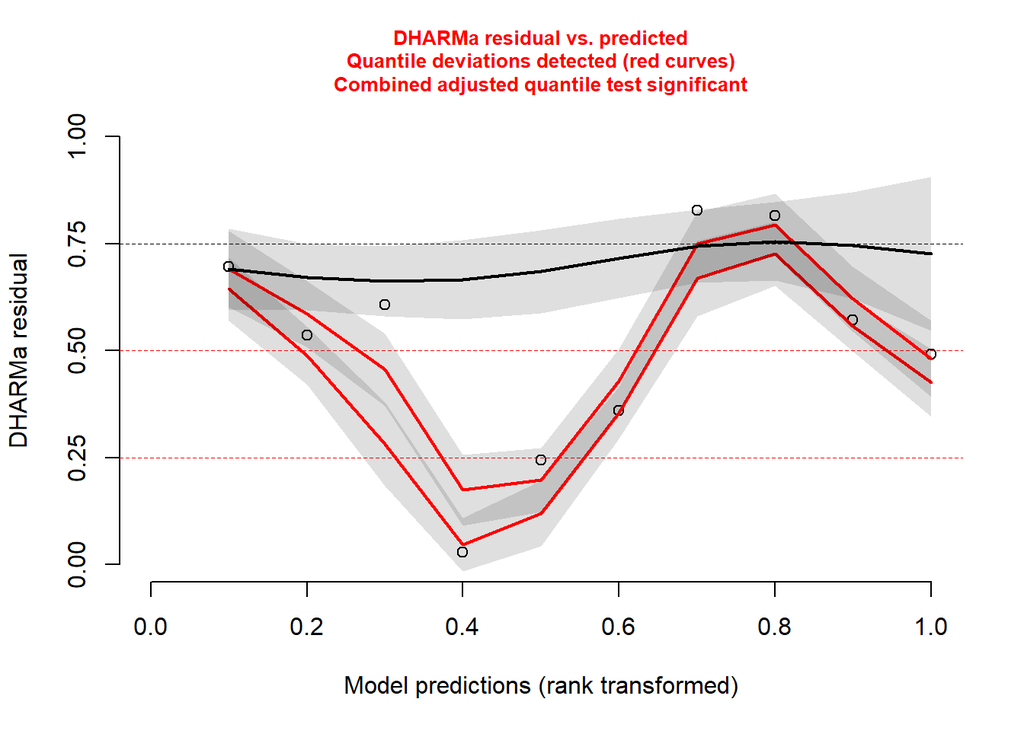

```r
plotResiduals(pH_fec_na_lm)
```

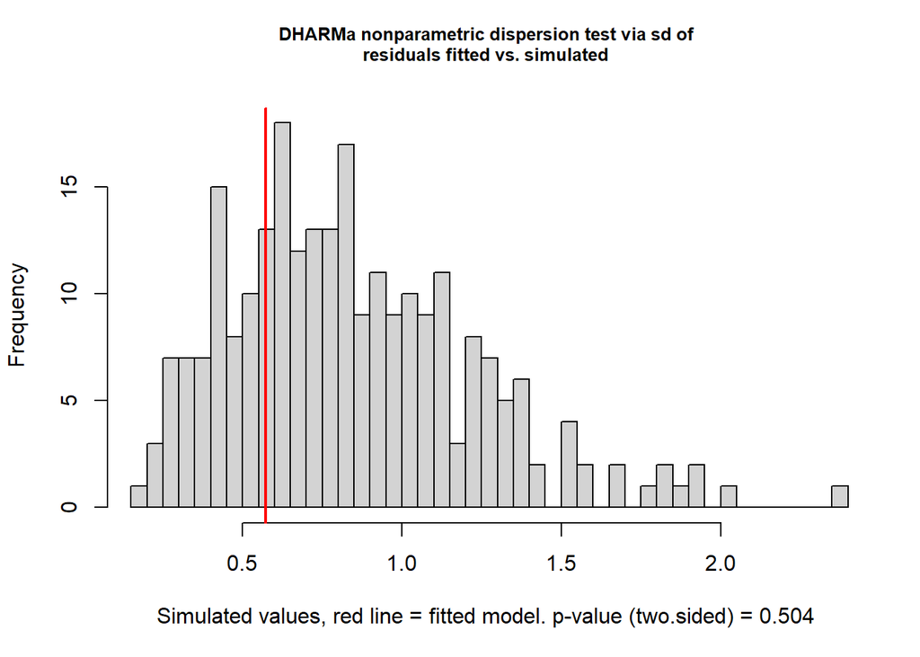

```
##
##  DHARMa nonparametric dispersion test via sd of residuals fitted vs.
##  simulated
##
## data:  simulationOutput
## dispersion = 0.67957, p-value = 0.504
## alternative hypothesis: two.sided
```

```r
testDispersion(pH_fec_na_lm)
```

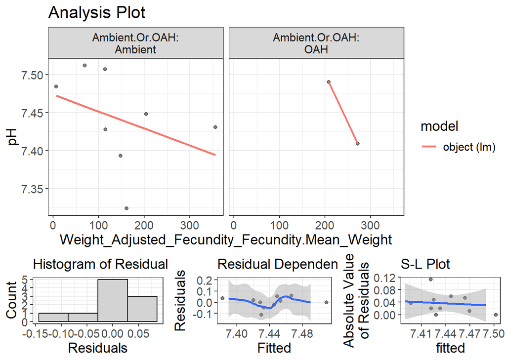

```r
visualize(pH_fec_na_lm)
```

```r
# Normality
shapiro.test(residuals(lm(pH ~ Ambient.Or.OAH * Weight_Adjusted_Fecundity_Fecundity.Mean_Weight, data = Fecundity_No_Atresia_Samples)))
```

```
##
##  Shapiro-Wilk normality test
##
## data:  residuals(lm(pH ~ Ambient.Or.OAH * Weight_Adjusted_Fecundity_Fecundity.Mean_Weight, data = Fecundity_No_Atresia_Samples))
## W = 0.91209, p-value = 0.2957
```

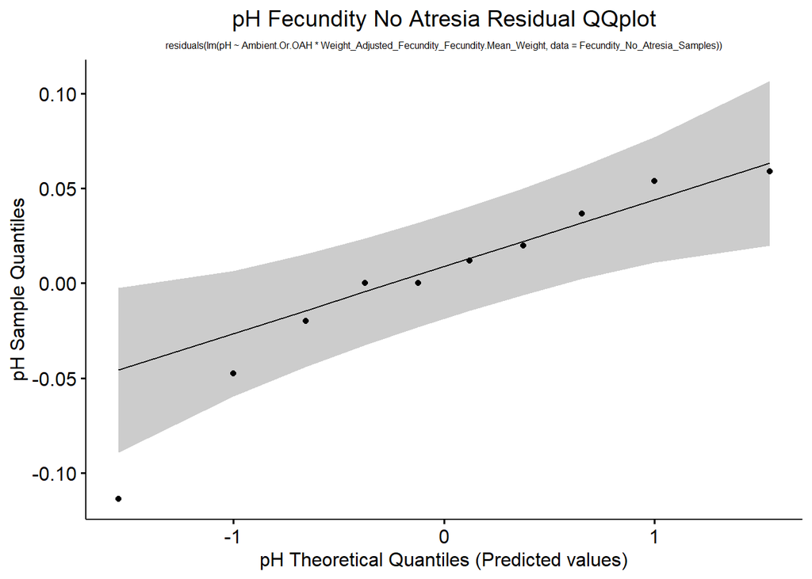

```r
# QQ plot
ggqqplot(residuals(lm(pH ~ Ambient.Or.OAH * Weight_Adjusted_Fecundity_Fecundity.Mean_Weight, data = Fecundity_No_Atresia_Samples))) +
labs(title = "pH Fecundity No Atresia Residual QQplot",
     subtitle = "residuals(lm(pH ~ Ambient.Or.OAH * Weight_Adjusted_Fecundity_Fecundity.Mean_Weight, data = Fecundity_No_Atresia_Samples))",
                               x = "pH Theoretical Quantiles (Predicted values)",
                               y = "pH Sample Quantiles") +
  theme(plot.title = element_text(hjust = 0.5),
        plot.subtitle = element_text(hjust = 0.5, size = 6))
```

```r
# Transform data: square root
pH_fec_na_sqrt <- Fecundity_No_Atresia_Samples %>%
  mutate(pH = sqrt(pH))

pH_fec_na_lm_sqrt <- lm(pH ~ Ambient.Or.OAH * Weight_Adjusted_Fecundity_Fecundity.Mean_Weight, data = pH_fec_na_sqrt)
summary(pH_fec_na_lm_sqrt)
```

```
##
## Call:
## lm(formula = pH ~ Ambient.Or.OAH * Weight_Adjusted_Fecundity_Fecundity.Mean_Weight,
##     data = pH_fec_na_sqrt)
##
## Residuals:
##       Min        1Q    Median        3Q       Max
## -0.020889 -0.002740  0.001099  0.005978  0.010787
##
## Coefficients:
##                                                                    Estimate
## (Intercept)                                                       2.7596209
## Ambient.Or.OAH.L                                                  0.0365920
## Weight_Adjusted_Fecundity_Fecundity.Mean_Weight                  -0.0001374
## Ambient.Or.OAH.L:Weight_Adjusted_Fecundity_Fecundity.Mean_Weight -0.0001366
##                                                                  Std. Error
## (Intercept)                                                       0.0314347
## Ambient.Or.OAH.L                                                  0.0444554
## Weight_Adjusted_Fecundity_Fecundity.Mean_Weight                   0.0001307
## Ambient.Or.OAH.L:Weight_Adjusted_Fecundity_Fecundity.Mean_Weight  0.0001849
##                                                                  t value
## (Intercept)                                                       87.789
## Ambient.Or.OAH.L                                                   0.823
## Weight_Adjusted_Fecundity_Fecundity.Mean_Weight                   -1.051
## Ambient.Or.OAH.L:Weight_Adjusted_Fecundity_Fecundity.Mean_Weight  -0.739
##                                                                  Pr(>|t|)
## (Intercept)                                                      1.47e-10 ***
## Ambient.Or.OAH.L                                                    0.442
## Weight_Adjusted_Fecundity_Fecundity.Mean_Weight                     0.334
## Ambient.Or.OAH.L:Weight_Adjusted_Fecundity_Fecundity.Mean_Weight    0.488
## ---
## Signif. codes:  0 '***' 0.001 '**' 0.01 '*' 0.05 '.' 0.1 ' ' 1
##
## Residual standard error: 0.01157 on 6 degrees of freedom
## Multiple R-squared:  0.2294, Adjusted R-squared:  -0.1559
## F-statistic: 0.5953 on 3 and 6 DF,  p-value: 0.6408
```

```
## qu = 0.25, log(sigma) = -3.378788 : outer Newton did not converge fully.
```

```
## qu = 0.5, log(sigma) = -3.478789 : outer Newton did not converge fully.
```

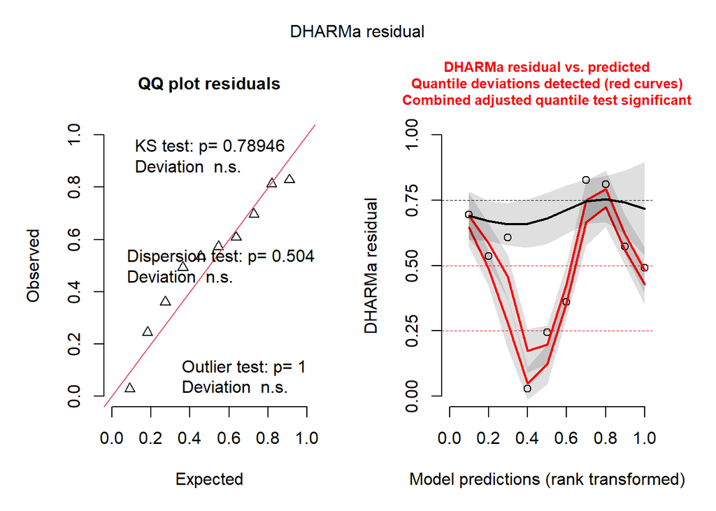

```r
pH_fec_na_sqrt_sim <- simulateResiduals(fittedModel = pH_fec_na_lm_sqrt)
plot(pH_fec_na_sqrt_sim)
```

```
## qu = 0.25, log(sigma) = -3.378788 : outer Newton did not converge fully.
## qu = 0.5, log(sigma) = -3.478789 : outer Newton did not converge fully.
```

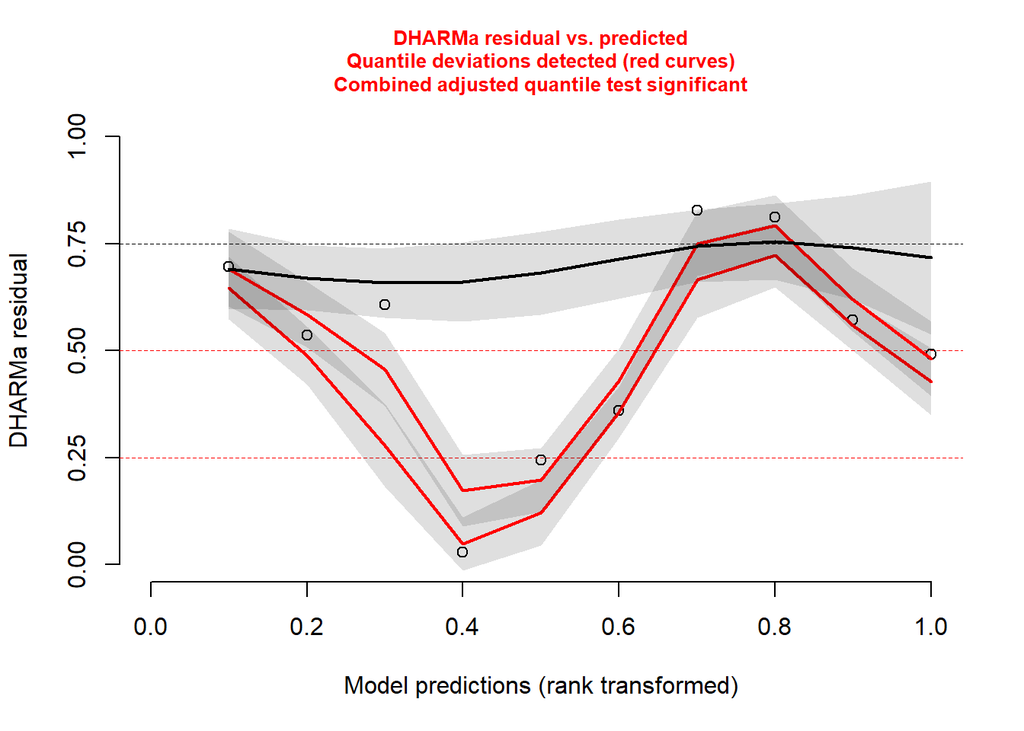

```r
plotResiduals(pH_fec_na_lm_sqrt)
```

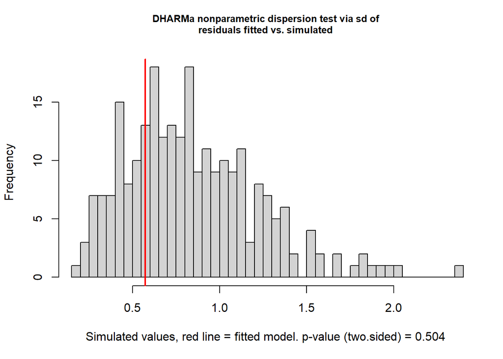

```
##
##  DHARMa nonparametric dispersion test via sd of residuals fitted vs.
##  simulated
##
## data:  simulationOutput
## dispersion = 0.67957, p-value = 0.504
## alternative hypothesis: two.sided
```

```r
testDispersion(pH_fec_na_lm_sqrt)
```

Residuals Plot (if significant)

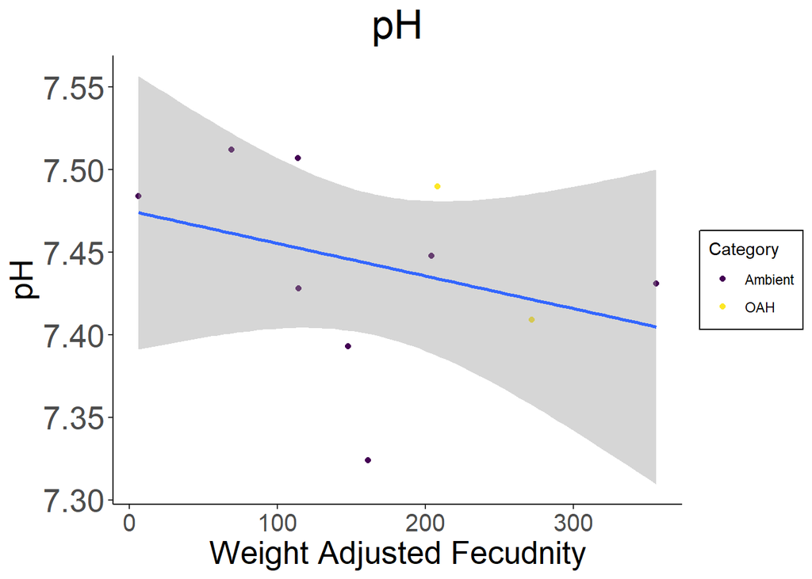

```r
# pH
# Ambient samples

# ggplot with geom_smooth(aes(x=,y=)), method = "lm")

pH_fec_na_lm_plot <- ggplot(data = Fecundity_No_Atresia_Samples, aes(x = Weight_Adjusted_Fecundity_Fecundity.Mean_Weight, y = pH)) +
  geom_point(aes(col = Ambient.Or.OAH)) +
  geom_smooth(aes(group = 1), method = "lm") +
  labs(title = "pH", x = "Weight Adjusted Fecudnity", y = "pH", color = "Category") +
  scale_y_continuous() +
  theme_classic() +
  theme(panel.background = element_rect(fill = "white"),
        plot.background = element_rect(fill = "white"),
        legend.background = element_rect(fill = "white", color = "black"),
        plot.title = element_text(size = 25, hjust = 0.5),
        axis.text.x = element_text(size = 15),
        axis.text.y = element_text(size = 20),
        axis.title.x = element_text(size = 20),
        axis.title.y = element_text(size = 20))

print(pH_fec_na_lm_plot)
```

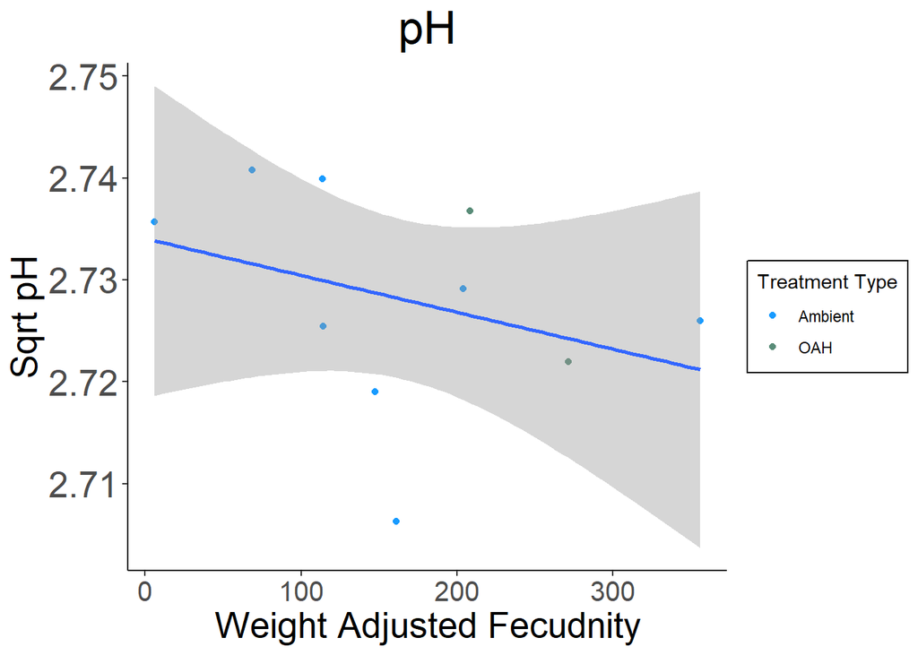

```r
ggsave(filename = "data-images/pH_fec_na_lm_plot.pdf", plot = pH_fec_na_lm_plot, device = "pdf")
ggsave(filename = "data-images/pH_fec_na_lm_plot.png", plot = pH_fec_na_lm_plot, device = "png")
ggplot(data = pH_fec_na_sqrt, aes(x = Weight_Adjusted_Fecundity_Fecundity.Mean_Weight, y = pH)) +
  geom_point(aes(col = Ambient.Or.OAH)) +
  geom_smooth(aes(group = 1), method = "lm") +
  labs(title = "pH", x = "Weight Adjusted Fecudnity", y = "Sqrt pH", color = "Category") +
  guides(color = guide_legend((title = "Treatment Type"))) +
  scale_color_manual(values = c("Ambient" = "#189bff", "OAH" = "#598c78")) +
  scale_y_continuous() +
  theme_classic() +
  theme(panel.background = element_rect(fill = "white"),
        plot.background = element_rect(fill = "white"),
        legend.background = element_rect(fill = "white", color = "black"),
        plot.title = element_text(size = 25, hjust = 0.5),
        axis.text.x = element_text(size = 15),
        axis.text.y = element_text(size = 20),
        axis.title.x = element_text(size = 20),
        axis.title.y = element_text(size = 20))
```

# Hct : Hematocrit

Hematocrit Summary Stats

```r
# hct
# Summary stats

# Ambient data
Fecundity_No_Atresia_Samples %>%
  group_by(Ambient.Or.OAH, Weight_Adjusted_Fecundity_Fecundity.Mean_Weight) %>%
  summarize(count = n(),
            median = round(median(Hct....), 3),
            mean = round(mean(Hct....), 3),
            sd = round(sd(Hct....), 3),
            cv = round(sd(Hct....)/mean(Hct....), 3)) %>%
  ungroup()
```

```
## # A tibble: 10 × 7
##    Ambient.Or.OAH Weight_Adjusted_Fecundity_Fec…¹ count median  mean    sd    cv
##    <ord>                                    <dbl> <int>  <dbl> <dbl> <dbl> <dbl>
##  1 Ambient                                   6.22     1    9.9   9.9    NA    NA
##  2 Ambient                                  68.8      1   12.9  12.9    NA    NA
##  3 Ambient                                 114.       1   21.7  21.7    NA    NA
##  4 Ambient                                 114.       1   16.4  16.4    NA    NA
##  5 Ambient                                 148.       1   14    14      NA    NA
##  6 Ambient                                 161.       1   14.6  14.6    NA    NA
##  7 Ambient                                 204.       1   12.3  12.3    NA    NA
##  8 Ambient                                 356.       1   18.2  18.2    NA    NA
##  9 OAH                                     208.       1   18.2  18.2    NA    NA
## 10 OAH                                     272.       1   14.4  14.4    NA    NA
## # ℹ abbreviated name: ¹Weight_Adjusted_Fecundity_Fecundity.Mean_Weight
```

Hematocrit scattterplot

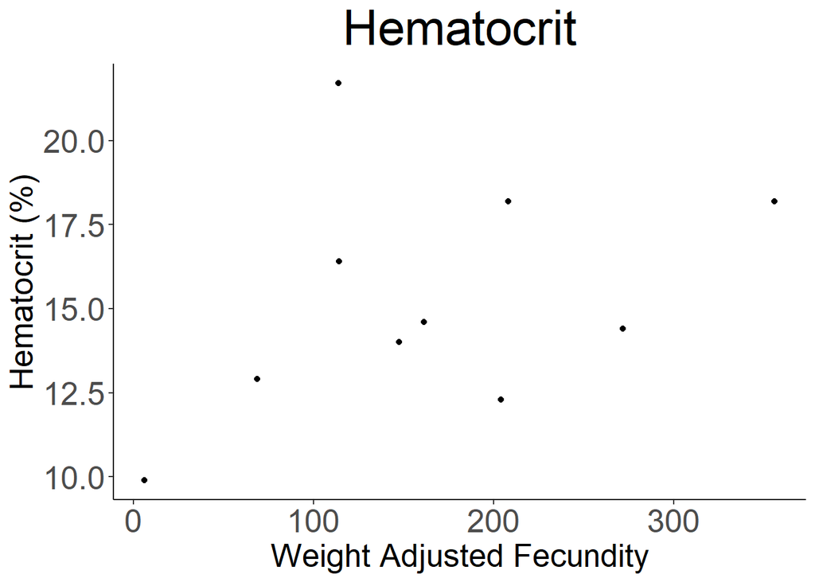

```r
# Hct
# Fecundity No Atresia Samples

# Scatterplot
hct_fec_na_scatterplot <- Fecundity_No_Atresia_Samples %>%
  ggplot() +
  geom_point(aes(x = Weight_Adjusted_Fecundity_Fecundity.Mean_Weight, y = Hct....), colour = "black") +
  labs(title = "Hematocrit", x = "Weight Adjusted Fecundity", y = "Hematocrit (%)") +
  theme_classic() +
  theme(panel.background = element_rect(fill = "white"),
        plot.background = element_rect(fill = "white"),
        legend.background = element_rect(fill = "white", color = "black"),
        title = element_text(size = 12),
        plot.title = element_text(size = 30, hjust = 0.5),
        axis.text.x = element_text(size = 20),
        axis.text.y = element_text(size = 20),
        axis.title.x = element_text(size = 20),
        axis.title.y = element_text(size = 20))

print(hct_fec_na_scatterplot)
```

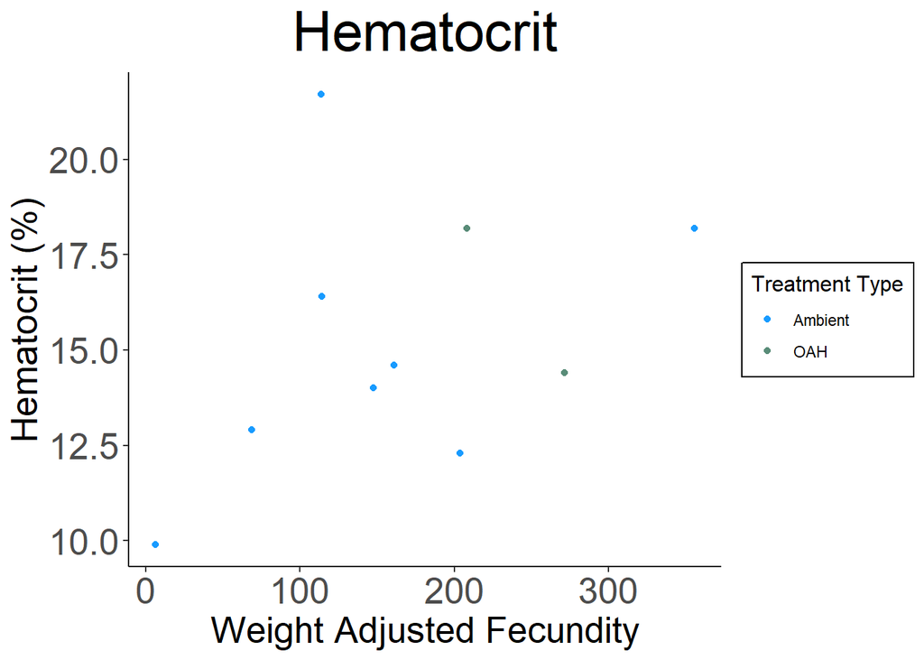

```r
ggsave(filename = "data-images/hct_fec_na_scatterplot.pdf", plot = hct_fec_na_scatterplot, device = "pdf")
ggsave(filename = "data-images/hct_fec_na_scatterplot.png", plot = hct_fec_na_scatterplot, device = "png")
# Color by treatment
hct_fec_na_scatterplot2 <- Fecundity_No_Atresia_Samples %>%
  ggplot() +
  geom_point(aes(x = Weight_Adjusted_Fecundity_Fecundity.Mean_Weight, y = Hct...., col = Ambient.Or.OAH)) +
  labs(title = "Hematocrit", x = "Weight Adjusted Fecundity", y = "Hematocrit (%)") +
  theme_classic() +
  guides(color = guide_legend((title = "Treatment Type"))) +
  scale_color_manual(values = c("Ambient" = "#189bff", "OAH" = "#598c78")) +
  theme(panel.background = element_rect(fill = "white"),
        plot.background = element_rect(fill = "white"),
        legend.background = element_rect(fill = "white", color = "black"),
        title = element_text(size = 12),
        plot.title = element_text(size = 30, hjust = 0.5),
        axis.text.x = element_text(size = 20),
        axis.text.y = element_text(size = 20),
        axis.title.x = element_text(size = 20),
        axis.title.y = element_text(size = 20))

print(hct_fec_na_scatterplot2)
```

# Hct Stat Tests

Weight Adjusted Fecundity, No Atresia

```r
# Hct
# Weight Adjusted Fecundity, No Atresia

# Fancy lm model

# Interactive
hct_fec_na_lm <- lm(Hct.... ~ Ambient.Or.OAH * Weight_Adjusted_Fecundity_Fecundity.Mean_Weight, data = Fecundity_No_Atresia_Samples)
summary(hct_fec_na_lm)
```

```
##
## Call:
## lm(formula = Hct.... ~ Ambient.Or.OAH * Weight_Adjusted_Fecundity_Fecundity.Mean_Weight,
##     data = Fecundity_No_Atresia_Samples)
##
## Residuals:
##     Min      1Q  Median      3Q     Max
## -3.5587 -0.9980 -0.3094  0.0541  7.1866
##
## Coefficients:
##                                                                  Estimate
## (Intercept)                                                      21.74296
## Ambient.Or.OAH.L                                                 12.63012
## Weight_Adjusted_Fecundity_Fecundity.Mean_Weight                  -0.02249
## Ambient.Or.OAH.L:Weight_Adjusted_Fecundity_Fecundity.Mean_Weight -0.05294
##                                                                  Std. Error
## (Intercept)                                                         9.87025
## Ambient.Or.OAH.L                                                   13.95864
## Weight_Adjusted_Fecundity_Fecundity.Mean_Weight                     0.04105
## Ambient.Or.OAH.L:Weight_Adjusted_Fecundity_Fecundity.Mean_Weight    0.05805
##                                                                  t value
## (Intercept)                                                        2.203
## Ambient.Or.OAH.L                                                   0.905
## Weight_Adjusted_Fecundity_Fecundity.Mean_Weight                   -0.548
## Ambient.Or.OAH.L:Weight_Adjusted_Fecundity_Fecundity.Mean_Weight  -0.912
##                                                                  Pr(>|t|)
## (Intercept)                                                        0.0698 .
## Ambient.Or.OAH.L                                                   0.4004
## Weight_Adjusted_Fecundity_Fecundity.Mean_Weight                    0.6035
## Ambient.Or.OAH.L:Weight_Adjusted_Fecundity_Fecundity.Mean_Weight   0.3970
## ---
## Signif. codes:  0 '***' 0.001 '**' 0.01 '*' 0.05 '.' 0.1 ' ' 1
##
## Residual standard error: 3.633 on 6 degrees of freedom
## Multiple R-squared:  0.2521, Adjusted R-squared:  -0.1218
## F-statistic: 0.6742 on 3 and 6 DF,  p-value: 0.5986
```

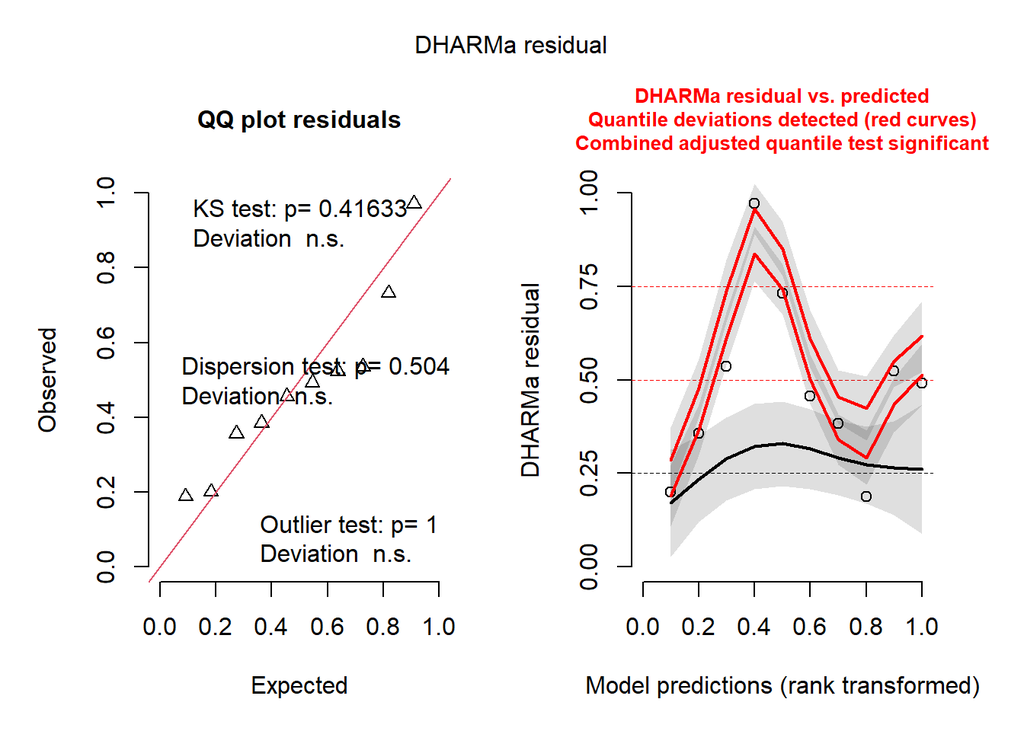

```r
hct_fec_na_lm_sim_res_plot <- simulateResiduals(fittedModel = hct_fec_na_lm)
plot(hct_fec_na_lm_sim_res_plot)
```

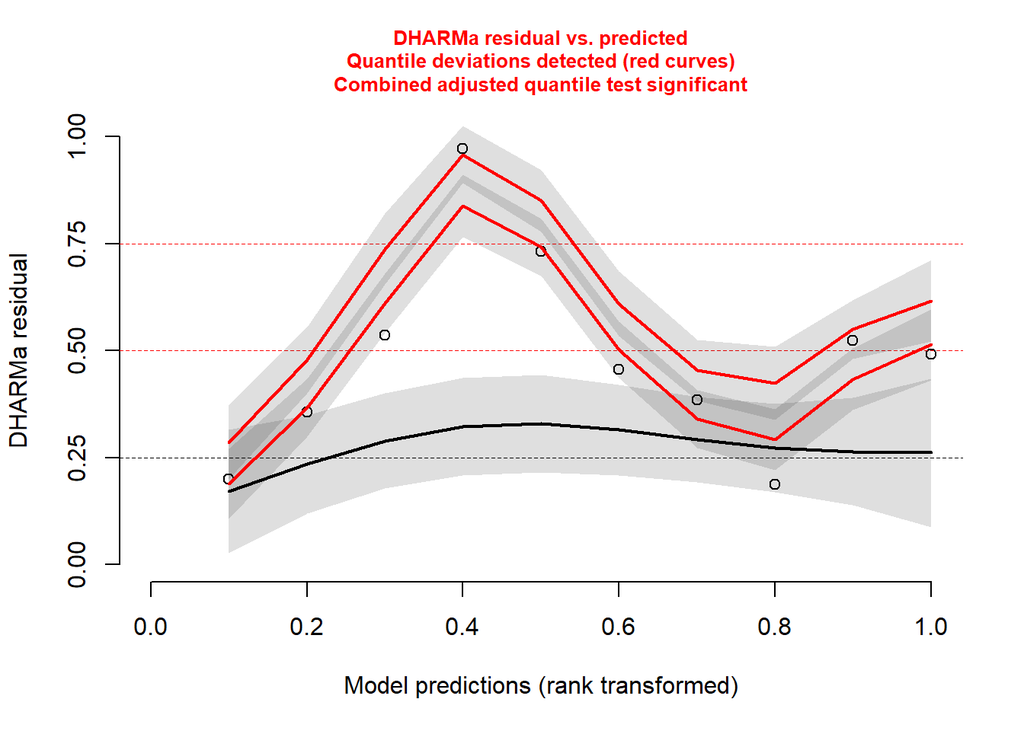

```r
plotResiduals(hct_fec_na_lm)
```

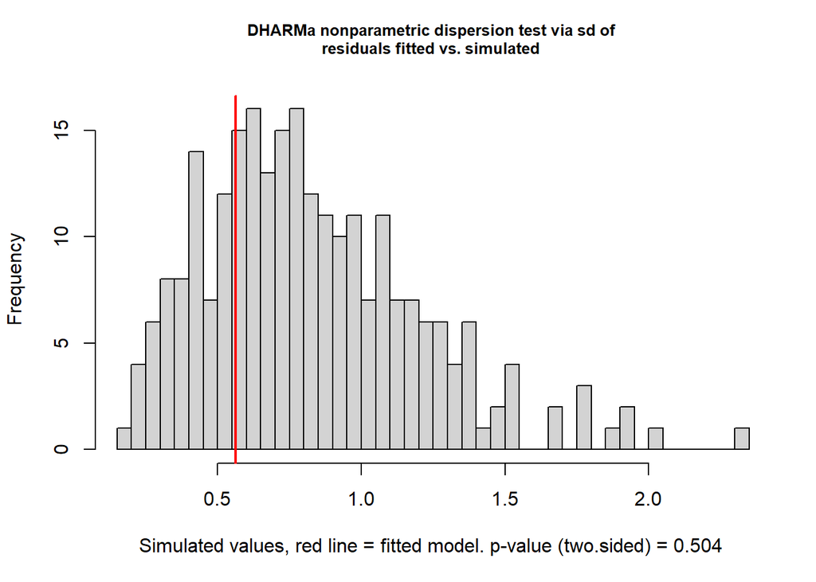

```
##
##  DHARMa nonparametric dispersion test via sd of residuals fitted vs.
##  simulated
##
## data:  simulationOutput
## dispersion = 0.67957, p-value = 0.504
## alternative hypothesis: two.sided
```

```r
testDispersion(hct_fec_na_lm)
```

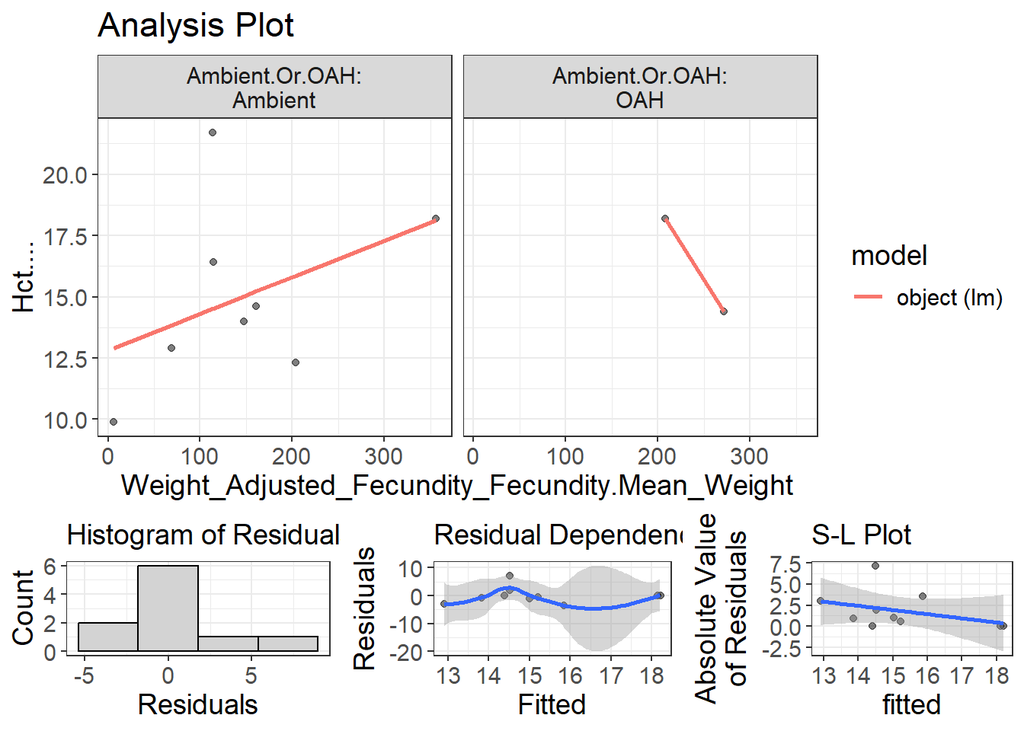

```r
visualize(hct_fec_na_lm)
```

```r
# Normality
shapiro.test(residuals(lm(Hct.... ~ Ambient.Or.OAH * Weight_Adjusted_Fecundity_Fecundity.Mean_Weight, data = Fecundity_No_Atresia_Samples)))
```

```
##
##  Shapiro-Wilk normality test
##
## data:  residuals(lm(Hct.... ~ Ambient.Or.OAH * Weight_Adjusted_Fecundity_Fecundity.Mean_Weight, data = Fecundity_No_Atresia_Samples))
## W = 0.83796, p-value = 0.0417
```

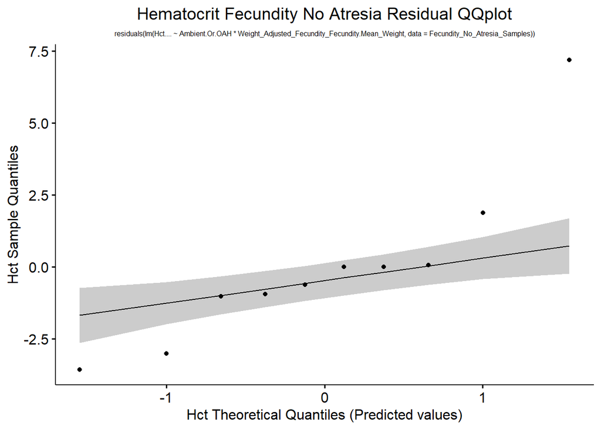

```r
# QQ plot
ggqqplot(residuals(lm(Hct.... ~ Ambient.Or.OAH * Weight_Adjusted_Fecundity_Fecundity.Mean_Weight, data = Fecundity_No_Atresia_Samples))) +
labs(title = "Hematocrit Fecundity No Atresia Residual QQplot",
     subtitle = "residuals(lm(Hct.... ~ Ambient.Or.OAH * Weight_Adjusted_Fecundity_Fecundity.Mean_Weight, data = Fecundity_No_Atresia_Samples))",
                               x = "Hct Theoretical Quantiles (Predicted values)",
                               y = "Hct Sample Quantiles") +
  theme(plot.title = element_text(hjust = 0.5),
        plot.subtitle = element_text(hjust = 0.5, size = 6))
```

```r
# Transform data: square root
hct_fec_na_sqrt <- Fecundity_No_Atresia_Samples %>%
  mutate(Hct.... = sqrt(Hct....))

hct_fec_na_lm_sqrt <- lm(Hct.... ~ Ambient.Or.OAH * Weight_Adjusted_Fecundity_Fecundity.Mean_Weight, data = hct_fec_na_sqrt)
summary(hct_fec_na_lm_sqrt)
```

```
##
## Call:
## lm(formula = Hct.... ~ Ambient.Or.OAH * Weight_Adjusted_Fecundity_Fecundity.Mean_Weight,
##     data = hct_fec_na_sqrt)
##
## Residuals:
##      Min       1Q   Median       3Q      Max
## -0.45751 -0.10588 -0.03198  0.00000  0.87682
##
## Coefficients:
##                                                                   Estimate
## (Intercept)                                                       4.681755
## Ambient.Or.OAH.L                                                  1.600665
## Weight_Adjusted_Fecundity_Fecundity.Mean_Weight                  -0.002700
## Ambient.Or.OAH.L:Weight_Adjusted_Fecundity_Fecundity.Mean_Weight -0.006695
##                                                                  Std. Error
## (Intercept)                                                        1.238841
## Ambient.Or.OAH.L                                                   1.751985
## Weight_Adjusted_Fecundity_Fecundity.Mean_Weight                    0.005152
## Ambient.Or.OAH.L:Weight_Adjusted_Fecundity_Fecundity.Mean_Weight   0.007287
##                                                                  t value
## (Intercept)                                                        3.779
## Ambient.Or.OAH.L                                                   0.914
## Weight_Adjusted_Fecundity_Fecundity.Mean_Weight                   -0.524
## Ambient.Or.OAH.L:Weight_Adjusted_Fecundity_Fecundity.Mean_Weight  -0.919
##                                                                  Pr(>|t|)
## (Intercept)                                                       0.00919 **
## Ambient.Or.OAH.L                                                  0.39614
## Weight_Adjusted_Fecundity_Fecundity.Mean_Weight                   0.61904
## Ambient.Or.OAH.L:Weight_Adjusted_Fecundity_Fecundity.Mean_Weight  0.39360
## ---
## Signif. codes:  0 '***' 0.001 '**' 0.01 '*' 0.05 '.' 0.1 ' ' 1
##
## Residual standard error: 0.456 on 6 degrees of freedom
## Multiple R-squared:  0.2759, Adjusted R-squared:  -0.08615
## F-statistic: 0.7621 on 3 and 6 DF,  p-value: 0.5552
```

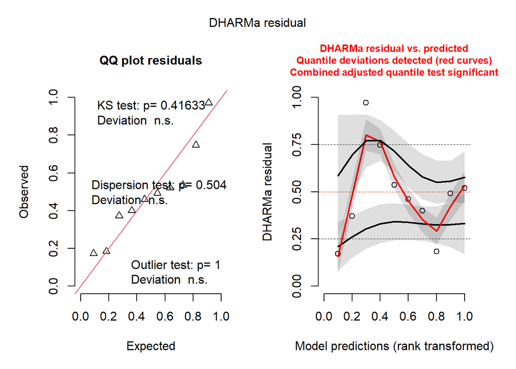

```r
hct_fec_na_sqrt_sim <- simulateResiduals(fittedModel = hct_fec_na_lm_sqrt)
plot(hct_fec_na_sqrt_sim)
```

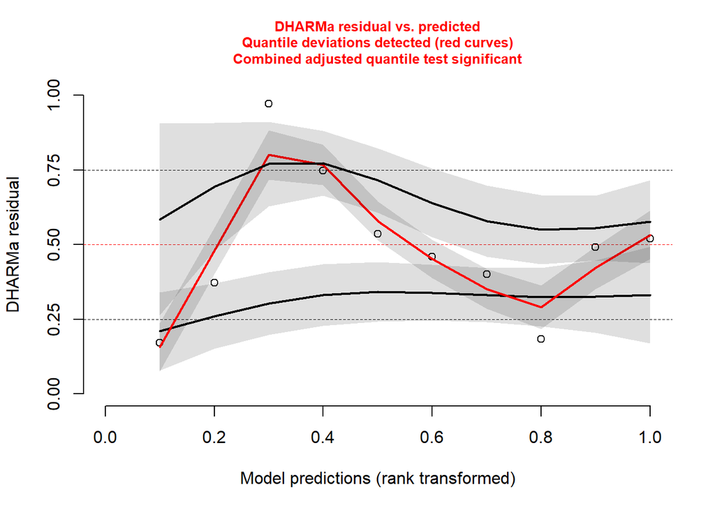

```r
plotResiduals(hct_fec_na_lm_sqrt)
```

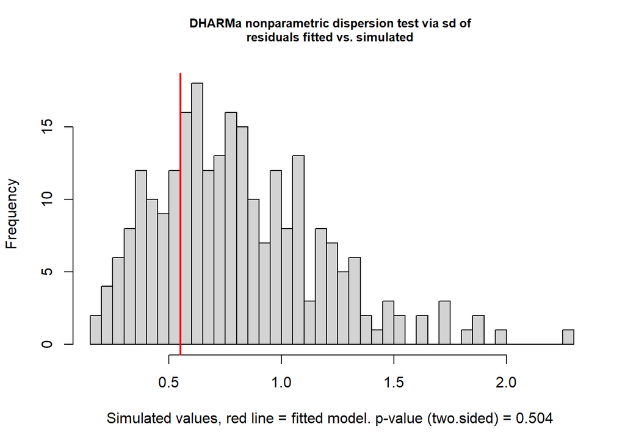

```
##
##  DHARMa nonparametric dispersion test via sd of residuals fitted vs.
##  simulated
##
## data:  simulationOutput
## dispersion = 0.67957, p-value = 0.504
## alternative hypothesis: two.sided
```

```r
testDispersion(hct_fec_na_lm_sqrt)
```

Residuals Plot (if significant)

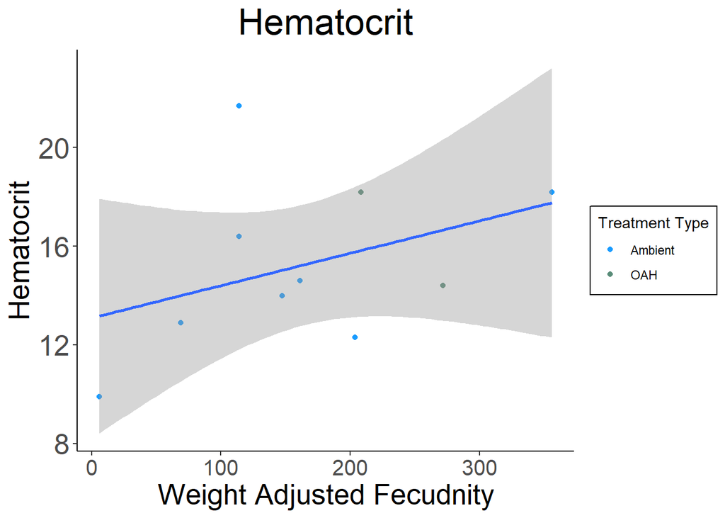

```r
# pH
# Ambient samples

# ggplot with geom_smooth(aes(x=,y=)), method = "lm")

hct_fec_na_lm_plot <- ggplot(data = Fecundity_No_Atresia_Samples, aes(x = Weight_Adjusted_Fecundity_Fecundity.Mean_Weight, y = Hct....)) +
  geom_point(aes(col = Ambient.Or.OAH)) +
  geom_smooth(aes(group = 1), method = "lm") +
  labs(title = "Hematocrit", x = "Weight Adjusted Fecudnity", y = "Hematocrit", color = "Category") +
  guides(color = guide_legend((title = "Treatment Type"))) +
  scale_color_manual(values = c("Ambient" = "#189bff", "OAH" = "#598c78")) +
  scale_y_continuous() +
  theme_classic() +
  theme(panel.background = element_rect(fill = "white"),
        plot.background = element_rect(fill = "white"),
        legend.background = element_rect(fill = "white", color = "black"),
        plot.title = element_text(size = 25, hjust = 0.5),
        axis.text.x = element_text(size = 15),
        axis.text.y = element_text(size = 20),
        axis.title.x = element_text(size = 20),
        axis.title.y = element_text(size = 20))

print(hct_fec_na_lm_plot)
```

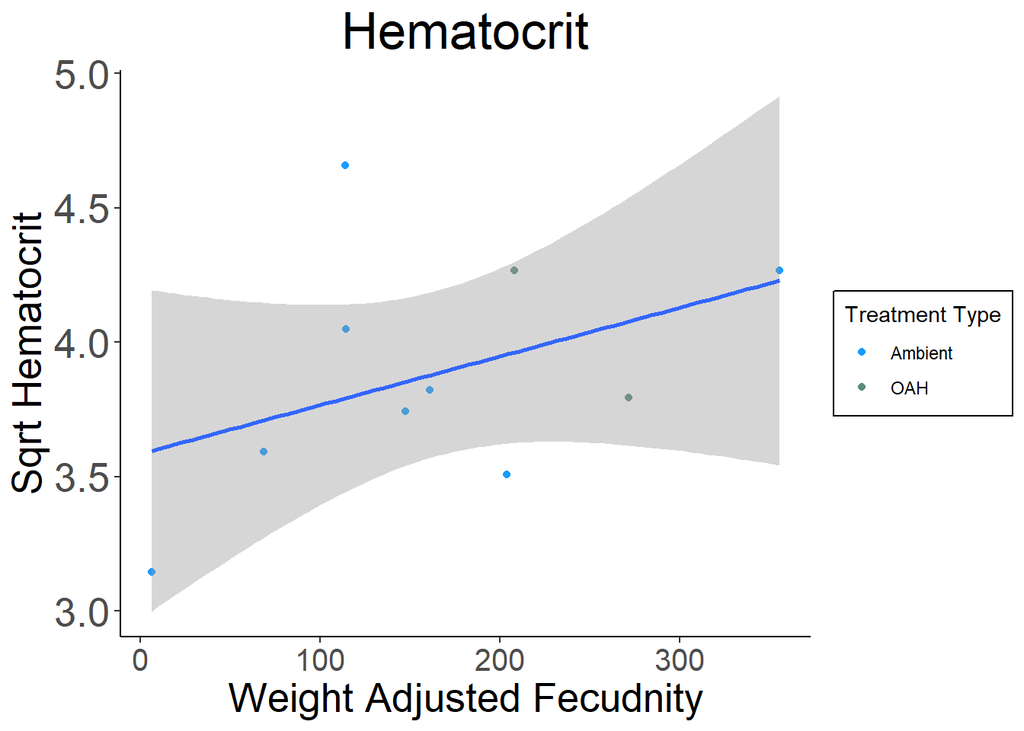

```r
ggsave(filename = "data-images/hct_fec_na_lm_plot.pdf", plot = hct_fec_na_lm_plot, device = "pdf")
ggsave(filename = "data-images/hct_fec_na_lm_plot.png", plot = hct_fec_na_lm_plot, device = "png")
ggplot(data = hct_fec_na_sqrt, aes(x = Weight_Adjusted_Fecundity_Fecundity.Mean_Weight, y = Hct....)) +
  geom_point(aes(col = Ambient.Or.OAH)) +
  geom_smooth(aes(group = 1), method = "lm") +
  labs(title = "Hematocrit", x = "Weight Adjusted Fecudnity", y = "Sqrt Hematocrit", color = "Category") +
  guides(color = guide_legend((title = "Treatment Type"))) +
  scale_color_manual(values = c("Ambient" = "#189bff", "OAH" = "#598c78")) +
  scale_y_continuous() +
  theme_classic() +
  theme(panel.background = element_rect(fill = "white"),
        plot.background = element_rect(fill = "white"),
        legend.background = element_rect(fill = "white", color = "black"),
        plot.title = element_text(size = 25, hjust = 0.5),
        axis.text.x = element_text(size = 15),
        axis.text.y = element_text(size = 20),
        axis.title.x = element_text(size = 20),
        axis.title.y = element_text(size = 20))
```

# Glucose

Glucose Summary Stats

```r
# glucose
# Summary stats

# Ambient data
Fecundity_No_Atresia_Samples %>%
  group_by(Ambient.Or.OAH, Weight_Adjusted_Fecundity_Fecundity.Mean_Weight) %>%
  summarize(count = n(),
            median = round(median(Glu..mmol.L.), 3),
            mean = round(mean(Glu..mmol.L.), 3),
            sd = round(sd(Glu..mmol.L.), 3),
            cv = round(sd(Glu..mmol.L.)/mean(Glu..mmol.L.), 3)) %>%
  ungroup()
```

```
## # A tibble: 10 × 7
##    Ambient.Or.OAH Weight_Adjusted_Fecundity_Fec…¹ count median  mean    sd    cv
##    <ord>                                    <dbl> <int>  <dbl> <dbl> <dbl> <dbl>
##  1 Ambient                                   6.22     1    1.1   1.1    NA    NA
##  2 Ambient                                  68.8      1    1.9   1.9    NA    NA
##  3 Ambient                                 114.       1    1.7   1.7    NA    NA
##  4 Ambient                                 114.       1    2.8   2.8    NA    NA
##  5 Ambient                                 148.       1    0.9   0.9    NA    NA
##  6 Ambient                                 161.       1    1.4   1.4    NA    NA
##  7 Ambient                                 204.       1    1.3   1.3    NA    NA
##  8 Ambient                                 356.       1    1.8   1.8    NA    NA
##  9 OAH                                     208.       1    1.6   1.6    NA    NA
## 10 OAH                                     272.       1    3.9   3.9    NA    NA
## # ℹ abbreviated name: ¹Weight_Adjusted_Fecundity_Fecundity.Mean_Weight
```

Glucose scattterplot

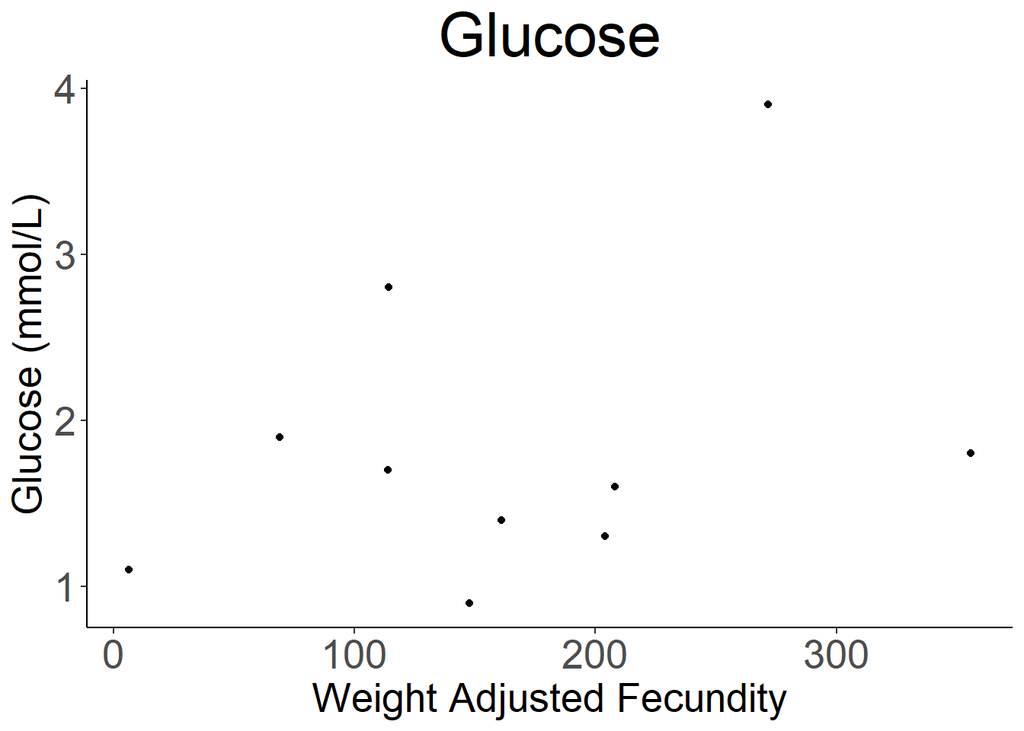

```r
# Hct
# Fecundity No Atresia Samples

# Scatterplot
glucose_fec_na_scatterplot <- Fecundity_No_Atresia_Samples %>%
  ggplot() +
  geom_point(aes(x = Weight_Adjusted_Fecundity_Fecundity.Mean_Weight, y = Glu..mmol.L.), colour = "black") +
  labs(title = "Glucose", x = "Weight Adjusted Fecundity", y = "Glucose (mmol/L)") +
  theme_classic() +
  theme(panel.background = element_rect(fill = "white"),
        plot.background = element_rect(fill = "white"),
        legend.background = element_rect(fill = "white", color = "black"),
        title = element_text(size = 12),
        plot.title = element_text(size = 30, hjust = 0.5),
        axis.text.x = element_text(size = 20),
        axis.text.y = element_text(size = 20),
        axis.title.x = element_text(size = 20),
        axis.title.y = element_text(size = 20))

print(glucose_fec_na_scatterplot)
```

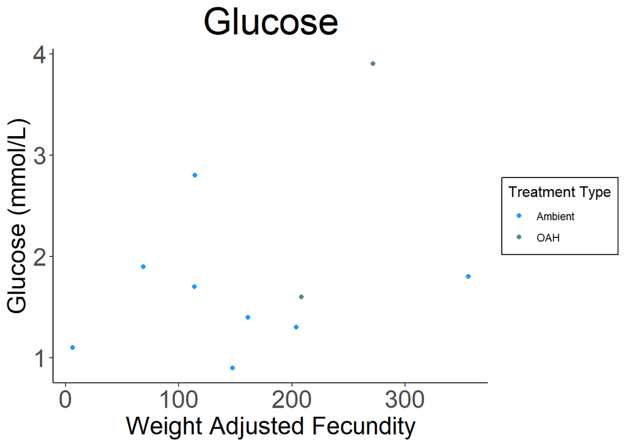

```r
ggsave(filename = "data-images/glucose_fec_na_scatterplot.pdf", plot = glucose_fec_na_scatterplot, device = "pdf")
ggsave(filename = "data-images/glucose_fec_na_scatterplot.png", plot = glucose_fec_na_scatterplot, device = "png")
# Color by treatment
glucose_fec_na_scatterplot2 <- Fecundity_No_Atresia_Samples %>%
  ggplot() +
  geom_point(aes(x = Weight_Adjusted_Fecundity_Fecundity.Mean_Weight, y = Glu..mmol.L., col = Ambient.Or.OAH)) +
  labs(title = "Glucose", x = "Weight Adjusted Fecundity", y = "Glucose (mmol/L)") +
  theme_classic() +
  guides(color = guide_legend((title = "Treatment Type"))) +
  scale_color_manual(values = c("Ambient" = "#189bff", "OAH" = "#598c78")) +
  theme(panel.background = element_rect(fill = "white"),
        plot.background = element_rect(fill = "white"),
        legend.background = element_rect(fill = "white", color = "black"),
        title = element_text(size = 12),
        plot.title = element_text(size = 30, hjust = 0.5),
        axis.text.x = element_text(size = 20),
        axis.text.y = element_text(size = 20),
        axis.title.x = element_text(size = 20),
        axis.title.y = element_text(size = 20))

print(glucose_fec_na_scatterplot2)
```

# Glucose Stat Tests

Weight Adjusted Fecundity, No Atresia

```r
# glucose
# Weight Adjusted Fecundity, No Atresia

# Fancy lm model

# Interactive
glucose_fec_na_lm <- lm(Glu..mmol.L. ~ Ambient.Or.OAH * Weight_Adjusted_Fecundity_Fecundity.Mean_Weight, data = Fecundity_No_Atresia_Samples)
summary(glucose_fec_na_lm)
```

```
##
## Call:
## lm(formula = Glu..mmol.L. ~ Ambient.Or.OAH * Weight_Adjusted_Fecundity_Fecundity.Mean_Weight,
##     data = Fecundity_No_Atresia_Samples)
##
## Residuals:
##     Min      1Q  Median      3Q     Max
## -0.7129 -0.3036  0.0000  0.1114  1.1986
##
## Coefficients:
##                                                                   Estimate
## (Intercept)                                                      -2.193867
## Ambient.Or.OAH.L                                                 -5.311885
## Weight_Adjusted_Fecundity_Fecundity.Mean_Weight                   0.018308
## Ambient.Or.OAH.L:Weight_Adjusted_Fecundity_Fecundity.Mean_Weight  0.025405
##                                                                  Std. Error
## (Intercept)                                                        1.732540
## Ambient.Or.OAH.L                                                   2.450182
## Weight_Adjusted_Fecundity_Fecundity.Mean_Weight                    0.007206
## Ambient.Or.OAH.L:Weight_Adjusted_Fecundity_Fecundity.Mean_Weight   0.010190
##                                                                  t value
## (Intercept)                                                       -1.266
## Ambient.Or.OAH.L                                                  -2.168
## Weight_Adjusted_Fecundity_Fecundity.Mean_Weight                    2.541
## Ambient.Or.OAH.L:Weight_Adjusted_Fecundity_Fecundity.Mean_Weight   2.493
##                                                                  Pr(>|t|)
## (Intercept)                                                        0.2524
## Ambient.Or.OAH.L                                                   0.0733 .
## Weight_Adjusted_Fecundity_Fecundity.Mean_Weight                    0.0440 *
## Ambient.Or.OAH.L:Weight_Adjusted_Fecundity_Fecundity.Mean_Weight   0.0470 *
## ---
## Signif. codes:  0 '***' 0.001 '**' 0.01 '*' 0.05 '.' 0.1 ' ' 1
##
## Residual standard error: 0.6377 on 6 degrees of freedom
## Multiple R-squared:  0.6594, Adjusted R-squared:  0.4891
## F-statistic: 3.872 on 3 and 6 DF,  p-value: 0.0745
```

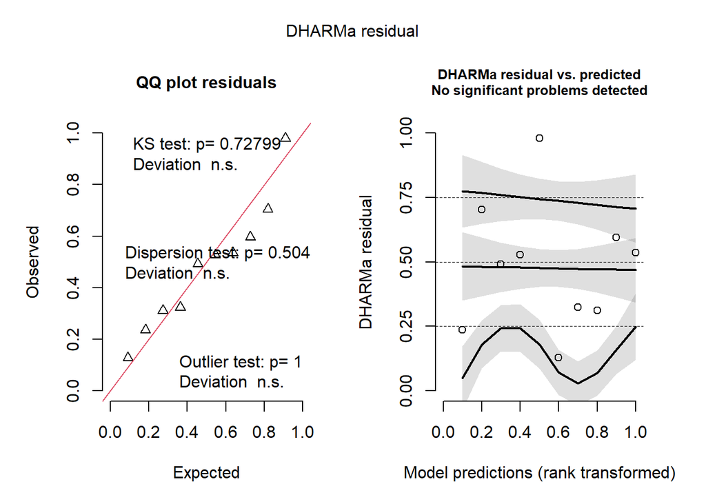

```r
glucose_fec_na_lm_sim_res_plot <- simulateResiduals(fittedModel = glucose_fec_na_lm)
plot(glucose_fec_na_lm_sim_res_plot)
```

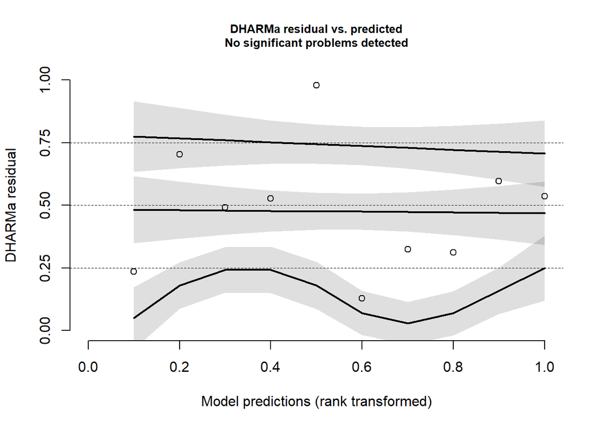

```r
plotResiduals(glucose_fec_na_lm)
```